# R Notebook

```r
library(tidyverse)
library(modelr)
library(ggiraphExtra)
library(GGally)
```

```r
kc_house <- read_csv("data/kc_house_data.csv")
```

```r
kc_house
```

| id | date | price | bedrooms | bathrooms | sqft_living | sqft_lot | floors | waterfront | view | condition | grade | sqft_above | sqft_basement | yr_built | yr_renovated | zipcode | lat | long | sqft_living15 | sqft_lot15 |
| --- | --- | --- | --- | --- | --- | --- | --- | --- | --- | --- | --- | --- | --- | --- | --- | --- | --- | --- | --- | --- |
| 7129300520 | 2014-10-13 | 221900 | 3 | 1.00 | 1180 | 5650 | 1.0 | 0 | 0 | 3 | 7 | 1180 | 0 | 1955 | 0 | 98178 | 47.5112 | -122.257 | 1340 | 5650 |
| 6414100192 | 2014-12-09 | 538000 | 3 | 2.25 | 2570 | 7242 | 2.0 | 0 | 0 | 3 | 7 | 2170 | 400 | 1951 | 1991 | 98125 | 47.7210 | -122.319 | 1690 | 7639 |
| 5631500400 | 2015-02-25 | 180000 | 2 | 1.00 | 770 | 10000 | 1.0 | 0 | 0 | 3 | 6 | 770 | 0 | 1933 | 0 | 98028 | 47.7379 | -122.233 | 2720 | 8062 |
| 2487200875 | 2014-12-09 | 604000 | 4 | 3.00 | 1960 | 5000 | 1.0 | 0 | 0 | 5 | 7 | 1050 | 910 | 1965 | 0 | 98136 | 47.5208 | -122.393 | 1360 | 5000 |
| 1954400510 | 2015-02-18 | 510000 | 3 | 2.00 | 1680 | 8080 | 1.0 | 0 | 0 | 3 | 8 | 1680 | 0 | 1987 | 0 | 98074 | 47.6168 | -122.045 | 1800 | 7503 |
| 7237550310 | 2014-05-12 | 1225000 | 4 | 4.50 | 5420 | 101930 | 1.0 | 0 | 0 | 3 | 11 | 3890 | 1530 | 2001 | 0 | 98053 | 47.6561 | -122.005 | 4760 | 101930 |
| 1321400060 | 2014-06-27 | 257500 | 3 | 2.25 | 1715 | 6819 | 2.0 | 0 | 0 | 3 | 7 | 1715 | 0 | 1995 | 0 | 98003 | 47.3097 | -122.327 | 2238 | 6819 |
| 2008000270 | 2015-01-15 | 291850 | 3 | 1.50 | 1060 | 9711 | 1.0 | 0 | 0 | 3 | 7 | 1060 | 0 | 1963 | 0 | 98198 | 47.4095 | -122.315 | 1650 | 9711 |
| 2414600126 | 2015-04-15 | 229500 | 3 | 1.00 | 1780 | 7470 | 1.0 | 0 | 0 | 3 | 7 | 1050 | 730 | 1960 | 0 | 98146 | 47.5123 | -122.337 | 1780 | 8113 |
| 3793500160 | 2015-03-12 | 323000 | 3 | 2.50 | 1890 | 6560 | 2.0 | 0 | 0 | 3 | 7 | 1890 | 0 | 2003 | 0 | 98038 | 47.3684 | -122.031 | 2390 | 7570 |

[output cut: 990 more lines]

```r
summary(kc_house)
```

```
      id                 date                         price            bedrooms
 Length:21613       Min.   :2014-05-02 00:00:00   Min.   :  75000   Min.   : 0.000
 Class :character   1st Qu.:2014-07-22 00:00:00   1st Qu.: 321950   1st Qu.: 3.000
 Mode  :character   Median :2014-10-16 00:00:00   Median : 450000   Median : 3.000
                    Mean   :2014-10-29 04:38:01   Mean   : 540088   Mean   : 3.371
                    3rd Qu.:2015-02-17 00:00:00   3rd Qu.: 645000   3rd Qu.: 4.000
                    Max.   :2015-05-27 00:00:00   Max.   :7700000   Max.   :33.000
   bathrooms      sqft_living       sqft_lot           floors        waterfront
 Min.   :0.000   Min.   :  290   Min.   :    520   Min.   :1.000   Min.   :0.000000
 1st Qu.:1.750   1st Qu.: 1427   1st Qu.:   5040   1st Qu.:1.000   1st Qu.:0.000000
 Median :2.250   Median : 1910   Median :   7618   Median :1.500   Median :0.000000
 Mean   :2.115   Mean   : 2080   Mean   :  15107   Mean   :1.494   Mean   :0.007542
 3rd Qu.:2.500   3rd Qu.: 2550   3rd Qu.:  10688   3rd Qu.:2.000   3rd Qu.:0.000000
 Max.   :8.000   Max.   :13540   Max.   :1651359   Max.   :3.500   Max.   :1.000000
      view          condition         grade          sqft_above   sqft_basement
 Min.   :0.0000   Min.   :1.000   Min.   : 1.000   Min.   : 290   Min.   :   0.0
 1st Qu.:0.0000   1st Qu.:3.000   1st Qu.: 7.000   1st Qu.:1190   1st Qu.:   0.0
 Median :0.0000   Median :3.000   Median : 7.000   Median :1560   Median :   0.0
 Mean   :0.2343   Mean   :3.409   Mean   : 7.657   Mean   :1788   Mean   : 291.5
 3rd Qu.:0.0000   3rd Qu.:4.000   3rd Qu.: 8.000   3rd Qu.:2210   3rd Qu.: 560.0
 Max.   :4.0000   Max.   :5.000   Max.   :13.000   Max.   :9410   Max.   :4820.0
    yr_built     yr_renovated       zipcode           lat             long
 Min.   :1900   Min.   :   0.0   Min.   :98001   Min.   :47.16   Min.   :-122.5
 1st Qu.:1951   1st Qu.:   0.0   1st Qu.:98033   1st Qu.:47.47   1st Qu.:-122.3
 Median :1975   Median :   0.0   Median :98065   Median :47.57   Median :-122.2
 Mean   :1971   Mean   :  84.4   Mean   :98078   Mean   :47.56   Mean   :-122.2
 3rd Qu.:1997   3rd Qu.:   0.0   3rd Qu.:98118   3rd Qu.:47.68   3rd Qu.:-122.1
 Max.   :2015   Max.   :2015.0   Max.   :98199   Max.   :47.78   Max.   :-121.3
 sqft_living15    sqft_lot15
 Min.   : 399   Min.   :   651
 1st Qu.:1490   1st Qu.:  5100
 Median :1840   Median :  7620
 Mean   :1987   Mean   : 12768
 3rd Qu.:2360   3rd Qu.: 10083
 Max.   :6210   Max.   :871200
```

Removal of some variable names

```r
kc_trim <- kc_house %>%
  select(-c(date, id, sqft_living15, sqft_lot15, zipcode))
```

```r
kc_trim
```

| price | bedrooms | bathrooms | sqft_living | sqft_lot | floors | waterfront | view | condition | grade | sqft_above | sqft_basement | yr_built | yr_renovated | lat | long |
| --- | --- | --- | --- | --- | --- | --- | --- | --- | --- | --- | --- | --- | --- | --- | --- |
| 221900 | 3 | 1.00 | 1180 | 5650 | 1.0 | 0 | 0 | 3 | 7 | 1180 | 0 | 1955 | 0 | 47.5112 | -122.257 |
| 538000 | 3 | 2.25 | 2570 | 7242 | 2.0 | 0 | 0 | 3 | 7 | 2170 | 400 | 1951 | 1991 | 47.7210 | -122.319 |
| 180000 | 2 | 1.00 | 770 | 10000 | 1.0 | 0 | 0 | 3 | 6 | 770 | 0 | 1933 | 0 | 47.7379 | -122.233 |
| 604000 | 4 | 3.00 | 1960 | 5000 | 1.0 | 0 | 0 | 5 | 7 | 1050 | 910 | 1965 | 0 | 47.5208 | -122.393 |
| 510000 | 3 | 2.00 | 1680 | 8080 | 1.0 | 0 | 0 | 3 | 8 | 1680 | 0 | 1987 | 0 | 47.6168 | -122.045 |
| 1225000 | 4 | 4.50 | 5420 | 101930 | 1.0 | 0 | 0 | 3 | 11 | 3890 | 1530 | 2001 | 0 | 47.6561 | -122.005 |
| 257500 | 3 | 2.25 | 1715 | 6819 | 2.0 | 0 | 0 | 3 | 7 | 1715 | 0 | 1995 | 0 | 47.3097 | -122.327 |
| 291850 | 3 | 1.50 | 1060 | 9711 | 1.0 | 0 | 0 | 3 | 7 | 1060 | 0 | 1963 | 0 | 47.4095 | -122.315 |
| 229500 | 3 | 1.00 | 1780 | 7470 | 1.0 | 0 | 0 | 3 | 7 | 1050 | 730 | 1960 | 0 | 47.5123 | -122.337 |
| 323000 | 3 | 2.50 | 1890 | 6560 | 2.0 | 0 | 0 | 3 | 7 | 1890 | 0 | 2003 | 0 | 47.3684 | -122.031 |

[output cut: 990 more lines]

looking at “Waterfront” it’s currently 1 or 0. I could change this to true or false or leave as is. As it is numeric and it’s easier to model using numbers, I will keep as is.

I am going to convert yr_renovated into “renovated”, a logical variable with a numerical form. 1 for having been revoated and 0 if not.

```r
kc_trim_dummy <- kc_trim %>%
  mutate(renovated = ifelse(yr_renovated > 0, 1, 0)) %>%
  select(-yr_renovated)
```

```r
kc_trim_dummy
```

| price | bedrooms | bathrooms | sqft_living | sqft_lot | floors | waterfront | view | condition | grade | sqft_above | sqft_basement | yr_built | lat | long | renovated |
| --- | --- | --- | --- | --- | --- | --- | --- | --- | --- | --- | --- | --- | --- | --- | --- |
| 221900 | 3 | 1.00 | 1180 | 5650 | 1.0 | 0 | 0 | 3 | 7 | 1180 | 0 | 1955 | 47.5112 | -122.257 | 0 |
| 538000 | 3 | 2.25 | 2570 | 7242 | 2.0 | 0 | 0 | 3 | 7 | 2170 | 400 | 1951 | 47.7210 | -122.319 | 1 |
| 180000 | 2 | 1.00 | 770 | 10000 | 1.0 | 0 | 0 | 3 | 6 | 770 | 0 | 1933 | 47.7379 | -122.233 | 0 |
| 604000 | 4 | 3.00 | 1960 | 5000 | 1.0 | 0 | 0 | 5 | 7 | 1050 | 910 | 1965 | 47.5208 | -122.393 | 0 |
| 510000 | 3 | 2.00 | 1680 | 8080 | 1.0 | 0 | 0 | 3 | 8 | 1680 | 0 | 1987 | 47.6168 | -122.045 | 0 |
| 1225000 | 4 | 4.50 | 5420 | 101930 | 1.0 | 0 | 0 | 3 | 11 | 3890 | 1530 | 2001 | 47.6561 | -122.005 | 0 |
| 257500 | 3 | 2.25 | 1715 | 6819 | 2.0 | 0 | 0 | 3 | 7 | 1715 | 0 | 1995 | 47.3097 | -122.327 | 0 |
| 291850 | 3 | 1.50 | 1060 | 9711 | 1.0 | 0 | 0 | 3 | 7 | 1060 | 0 | 1963 | 47.4095 | -122.315 | 0 |
| 229500 | 3 | 1.00 | 1780 | 7470 | 1.0 | 0 | 0 | 3 | 7 | 1050 | 730 | 1960 | 47.5123 | -122.337 | 0 |
| 323000 | 3 | 2.50 | 1890 | 6560 | 2.0 | 0 | 0 | 3 | 7 | 1890 | 0 | 2003 | 47.3684 | -122.031 | 0 |

[output cut: 990 more lines]

Looking at variables condition and grade, I found this information:

https://rstudio-pubs-static.s3.amazonaws.com/155304_cc51f448116744069664b35e7762999f.html

grade - An index from 1 to 13, where 1-3 falls short of building construction and design, 7 has an average level of construction and design, and 11-13 have a high quality level of construction and design.

condition - An index from 1 to 5 on the condition of the apartment,

Therefore I am satisifed that they are sequential categorical ordinal data types.

Using the alias function, I will check for aliased variables:

```r
alias(lm, kc_trim_dummy)
```

```
Error in UseMethod("alias") :
  no applicable method for 'alias' applied to an object of class "function"
```

```r
alias(price ~ condition, kc_trim_dummy)
```

```
Model :
price ~ condition
```

```r
alias(price ~ bedrooms, kc_trim_dummy)
```

```
Model :
price ~ bedrooms
```

```r
alias(price ~ bathrooms, kc_trim_dummy)
```

```
Model :
price ~ bathrooms
```

```r
alias(price ~ sqft_living, kc_trim_dummy)
```

```
Model :
price ~ sqft_living
```

```r
alias(price ~ sqft_lot, kc_trim_dummy)
```

```
Model :
price ~ sqft_lot
```

```r
alias(price ~ floors, kc_trim_dummy)
```

```
Model :
price ~ floors
```

```r
alias(price ~ waterfront, kc_trim_dummy)
```

```
Model :
price ~ waterfront
```

```r
alias(price ~ view, kc_trim_dummy)
```

```
Model :
price ~ view
```

```r
alias(price ~ condition, kc_trim_dummy)
```

```
Model :
price ~ condition
```

```r
alias(price ~ grade, kc_trim_dummy)
```

```
Model :
price ~ grade
```

```r
alias(price ~ sqft_above, kc_trim_dummy)
```

```
Model :
price ~ sqft_above
```

```r
alias(price ~ sqft_basement, kc_trim_dummy)
```

```
Model :
price ~ sqft_basement
```

```r
alias(price ~ yr_built, kc_trim_dummy)
```

```
Model :
price ~ yr_built
```

```r
alias(price ~ lat, kc_trim_dummy)
```

```
Model :
price ~ lat
```

```r
alias(price ~ long, kc_trim_dummy)
```

```
Model :
price ~ long
```

```r
alias(price ~ renovated, kc_trim_dummy)
```

```
Model :
price ~ renovated
```

I cannot find a variable that leads to an alias so I haven’t removed anything.

I will now consider building the regression model by examining what variables are strongly correlated to price.

[figure not shown]

```r
kc_trim_dummy %>%
  ggpairs(aes())
```

As this impossible to read, I am going to split the variables by numeric and non-numeric.

[figure not shown]

```r
kc_trim_numeric <- kc_trim_dummy %>%
  select_if(is.numeric)

kc_trim_nonnumeric <- kc_trim_dummy %>%
  select_if(function(x) !is.numeric(x))

kc_trim_nonnumeric$price <- kc_trim_dummy$price

ggpairs(kc_trim_numeric)
```

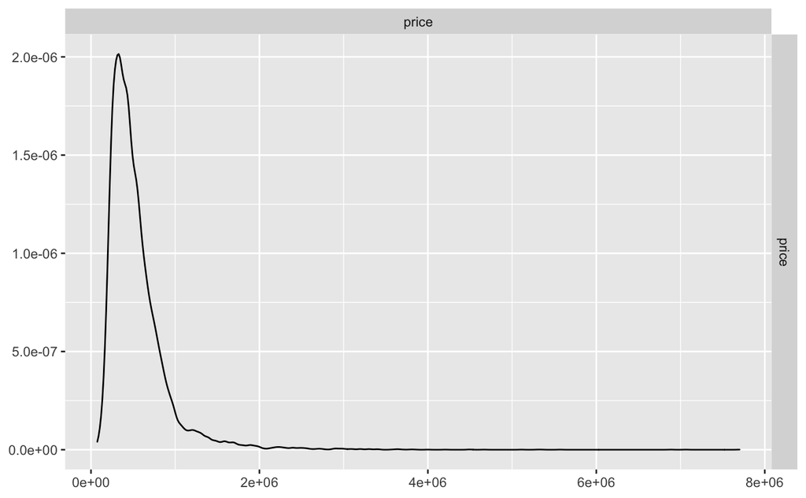

```r
ggpairs(kc_trim_nonnumeric)
```

I cannot seem to see which variables have a strong indication of a strong correlation to “price”. Hence I will build the model trying to use my commonsense.

```r
kc_mod1 <- lm(price ~ yr_built, data = kc_trim_dummy)
kc_mod1
```

```
Call:
lm(formula = price ~ yr_built, data = kc_trim_dummy)

Coefficients:
(Intercept)     yr_built
  -790477.9        675.1
```

```r
summary(kc_mod1)
```

```
Call:
lm(formula = price ~ yr_built, data = kc_trim_dummy)

Residuals:
    Min      1Q  Median      3Q     Max
-461709 -221337  -87006  104064 7201095

Coefficients:
             Estimate Std. Error t value Pr(>|t|)
(Intercept) -790477.9   167350.2  -4.723 2.33e-06 ***
yr_built        675.1       84.9   7.952 1.93e-15 ***
---
Signif. codes:  0 ‘***’ 0.001 ‘**’ 0.01 ‘*’ 0.05 ‘.’ 0.1 ‘ ’ 1

Residual standard error: 366600 on 21611 degrees of freedom
Multiple R-squared:  0.002917,  Adjusted R-squared:  0.002871
F-statistic: 63.23 on 1 and 21611 DF,  p-value: 1.93e-15
```

OK the figure for R squared is very low so this has very correlation.

```r
kc_mod2 <- lm(price ~ bedrooms, data = kc_trim_dummy)
kc_mod2
```

```
Call:
lm(formula = price ~ bedrooms, data = kc_trim_dummy)

Coefficients:
(Intercept)     bedrooms
     129802       121716
```

```r
summary(kc_mod2)
```

```
Call:
lm(formula = price ~ bedrooms, data = kc_trim_dummy)

Residuals:
     Min       1Q   Median       3Q      Max
-3506435  -203235   -66667   105049  6839901

Coefficients:
            Estimate Std. Error t value Pr(>|t|)
(Intercept)   129802       8932   14.53   <2e-16 ***
bedrooms      121716       2554   47.65   <2e-16 ***
---
Signif. codes:  0 ‘***’ 0.001 ‘**’ 0.01 ‘*’ 0.05 ‘.’ 0.1 ‘ ’ 1

Residual standard error: 349200 on 21611 degrees of freedom
Multiple R-squared:  0.09508,   Adjusted R-squared:  0.09504
F-statistic:  2271 on 1 and 21611 DF,  p-value: < 2.2e-16
```

```r
kc_mod3 <- lm(price ~ bathrooms, data = kc_trim_dummy)
kc_mod3
```

```
Call:
lm(formula = price ~ bathrooms, data = kc_trim_dummy)

Coefficients:
(Intercept)    bathrooms
      10708       250327
```

```r
summary(kc_mod3)
```

```
Call:
lm(formula = price ~ bathrooms, data = kc_trim_dummy)

Residuals:
     Min       1Q   Median       3Q      Max
-1438157  -184525   -41525   113220  5925322

Coefficients:
            Estimate Std. Error t value Pr(>|t|)
(Intercept)    10708       6211   1.724   0.0847 .
bathrooms     250326       2760  90.714   <2e-16 ***
---
Signif. codes:  0 ‘***’ 0.001 ‘**’ 0.01 ‘*’ 0.05 ‘.’ 0.1 ‘ ’ 1

Residual standard error: 312400 on 21611 degrees of freedom
Multiple R-squared:  0.2758,    Adjusted R-squared:  0.2757
F-statistic:  8229 on 1 and 21611 DF,  p-value: < 2.2e-16
```

Bathrooms had a higher R squared comparison % bit still quite low.

```r
kc_mod4 <- lm(price ~ sqft_living, data = kc_trim_dummy)
kc_mod4
```

```
Call:
lm(formula = price ~ sqft_living, data = kc_trim_dummy)

Coefficients:
(Intercept)  sqft_living
   -43580.7        280.6
```

```r
summary(kc_mod4)
```

```
Call:
lm(formula = price ~ sqft_living, data = kc_trim_dummy)

Residuals:
     Min       1Q   Median       3Q      Max
-1476062  -147486   -24043   106182  4362067

Coefficients:
              Estimate Std. Error t value Pr(>|t|)
(Intercept) -43580.743   4402.690  -9.899   <2e-16 ***
sqft_living    280.624      1.936 144.920   <2e-16 ***
---
Signif. codes:  0 ‘***’ 0.001 ‘**’ 0.01 ‘*’ 0.05 ‘.’ 0.1 ‘ ’ 1

Residual standard error: 261500 on 21611 degrees of freedom
Multiple R-squared:  0.4929,    Adjusted R-squared:  0.4928
F-statistic: 2.1e+04 on 1 and 21611 DF,  p-value: < 2.2e-16
```

sqft_living is higher again at 0.49 R-squared.

```r
kc_mod5 <- lm(price ~ sqft_lot, data = kc_trim_dummy)
kc_mod5
```

```
Call:
lm(formula = price ~ sqft_lot, data = kc_trim_dummy)

Coefficients:
(Intercept)     sqft_lot
  5.281e+05    7.947e-01
```

```r
summary(kc_mod5)
```

```
Call:
lm(formula = price ~ sqft_lot, data = kc_trim_dummy)

Residuals:
     Min       1Q   Median       3Q      Max
-1263746  -216163   -87467   103143  7149984

Coefficients:
             Estimate Std. Error t value Pr(>|t|)
(Intercept) 5.281e+05  2.648e+03  199.46   <2e-16 ***
sqft_lot    7.947e-01  6.005e-02   13.23   <2e-16 ***
---
Signif. codes:  0 ‘***’ 0.001 ‘**’ 0.01 ‘*’ 0.05 ‘.’ 0.1 ‘ ’ 1

Residual standard error: 365700 on 21611 degrees of freedom
Multiple R-squared:  0.008039,  Adjusted R-squared:  0.007993
F-statistic: 175.1 on 1 and 21611 DF,  p-value: < 2.2e-16
```

Again this is low

```r
kc_mod6 <- lm(price ~ floors, data = kc_trim_dummy)
kc_mod6
```

```
Call:
lm(formula = price ~ floors, data = kc_trim_dummy)

Coefficients:
(Intercept)       floors
     279199       174589
```

```r
summary(kc_mod6)
```

```
Call:
lm(formula = price ~ floors, data = kc_trim_dummy)

Residuals:
    Min      1Q  Median      3Q     Max
-597965 -203837  -73787  103213 6984329

Coefficients:
            Estimate Std. Error t value Pr(>|t|)
(Intercept)   279198       7102   39.31   <2e-16 ***
floors        174589       4470   39.06   <2e-16 ***
---
Signif. codes:  0 ‘***’ 0.001 ‘**’ 0.01 ‘*’ 0.05 ‘.’ 0.1 ‘ ’ 1

Residual standard error: 354800 on 21611 degrees of freedom
Multiple R-squared:  0.06594,   Adjusted R-squared:  0.0659
F-statistic:  1526 on 1 and 21611 DF,  p-value: < 2.2e-16
```

```r
kc_mod7 <- lm(price ~ waterfront, data = kc_trim_dummy)
kc_mod7
```

```
Call:
lm(formula = price ~ waterfront, data = kc_trim_dummy)

Coefficients:
(Intercept)   waterfront
     531564      1130312
```

```r
summary(kc_mod7)
```

```
Call:
lm(formula = price ~ waterfront, data = kc_trim_dummy)

Residuals:
     Min       1Q   Median       3Q      Max
-1376876  -211564   -81564   108436  7168436

Coefficients:
            Estimate Std. Error t value Pr(>|t|)
(Intercept)   531564       2416  220.00   <2e-16 ***
waterfront   1130312      27822   40.63   <2e-16 ***
---
Signif. codes:  0 ‘***’ 0.001 ‘**’ 0.01 ‘*’ 0.05 ‘.’ 0.1 ‘ ’ 1

Residual standard error: 353900 on 21611 degrees of freedom
Multiple R-squared:  0.07095,   Adjusted R-squared:  0.07091
F-statistic:  1650 on 1 and 21611 DF,  p-value: < 2.2e-16
```

```r
kc_mod8 <- lm(price ~ view, data = kc_trim_dummy)
kc_mod8
```

```
Call:
lm(formula = price ~ view, data = kc_trim_dummy)

Coefficients:
(Intercept)         view
     495492       190335
```

```r
summary(kc_mod8)
```

```
Call:
lm(formula = price ~ view, data = kc_trim_dummy)

Residuals:
     Min       1Q   Median       3Q      Max
-1004833  -195492   -67492   109508  6633502

Coefficients:
            Estimate Std. Error t value Pr(>|t|)
(Intercept)   495492       2396  206.76   <2e-16 ***
view          190335       2991   63.64   <2e-16 ***
---
Signif. codes:  0 ‘***’ 0.001 ‘**’ 0.01 ‘*’ 0.05 ‘.’ 0.1 ‘ ’ 1

Residual standard error: 336900 on 21611 degrees of freedom
Multiple R-squared:  0.1578,    Adjusted R-squared:  0.1578
F-statistic:  4050 on 1 and 21611 DF,  p-value: < 2.2e-16
```

```r
kc_mod9 <- lm(price ~ condition, data = kc_trim_dummy)
kc_mod9
```

```
Call:
lm(formula = price ~ condition, data = kc_trim_dummy)

Coefficients:
(Intercept)    condition
     470147        20514
```

```r
summary(kc_mod9)
```

```
Call:
lm(formula = price ~ condition, data = kc_trim_dummy)

Residuals:
    Min      1Q  Median      3Q     Max
-463203 -217203  -87203  101797 7147797

Coefficients:
            Estimate Std. Error t value Pr(>|t|)
(Intercept)   470147      13312  35.318  < 2e-16 ***
condition      20514       3835   5.349 8.94e-08 ***
---
Signif. codes:  0 ‘***’ 0.001 ‘**’ 0.01 ‘*’ 0.05 ‘.’ 0.1 ‘ ’ 1

Residual standard error: 366900 on 21611 degrees of freedom
Multiple R-squared:  0.001322,  Adjusted R-squared:  0.001276
F-statistic: 28.61 on 1 and 21611 DF,  p-value: 8.936e-08
```

```r
kc_mod10 <- lm(price ~ grade, data = kc_trim_dummy)
kc_mod10
```

```
Call:
lm(formula = price ~ grade, data = kc_trim_dummy)

Coefficients:
(Intercept)        grade
   -1056045       208458
```

```r
summary(kc_mod10)
```

```
Call:
lm(formula = price ~ grade, data = kc_trim_dummy)

Residuals:
    Min      1Q  Median      3Q     Max
-816988 -151958  -36158   97842 6046097

Coefficients:
            Estimate Std. Error t value Pr(>|t|)
(Intercept) -1056045      12256  -86.17   <2e-16 ***
grade         208458       1582  131.76   <2e-16 ***
---
Signif. codes:  0 ‘***’ 0.001 ‘**’ 0.01 ‘*’ 0.05 ‘.’ 0.1 ‘ ’ 1

Residual standard error: 273400 on 21611 degrees of freedom
Multiple R-squared:  0.4455,    Adjusted R-squared:  0.4454
F-statistic: 1.736e+04 on 1 and 21611 DF,  p-value: < 2.2e-16
```

Grade is a bit more correlated.

```r
kc_mod11 <- lm(price ~ sqft_above, data = kc_trim_dummy)
kc_mod11
```

```
Call:
lm(formula = price ~ sqft_above, data = kc_trim_dummy)

Coefficients:
(Intercept)   sqft_above
    59953.2        268.5
```

```r
summary(kc_mod11)
```

```
Call:
lm(formula = price ~ sqft_above, data = kc_trim_dummy)

Residuals:
    Min      1Q  Median      3Q     Max
-913132 -165624  -41468  109327 5339232

Coefficients:
            Estimate Std. Error t value Pr(>|t|)
(Intercept)  59953.2     4729.8   12.68   <2e-16 ***
sqft_above     268.5        2.4  111.87   <2e-16 ***
---
Signif. codes:  0 ‘***’ 0.001 ‘**’ 0.01 ‘*’ 0.05 ‘.’ 0.1 ‘ ’ 1

Residual standard error: 292200 on 21611 degrees of freedom
Multiple R-squared:  0.3667,    Adjusted R-squared:  0.3667
F-statistic: 1.251e+04 on 1 and 21611 DF,  p-value: < 2.2e-16
```

```r
kc_mod12 <- lm(price ~ sqft_basement, data = kc_trim_dummy)
kc_mod12
```

```
Call:
lm(formula = price ~ sqft_basement, data = kc_trim_dummy)

Coefficients:
  (Intercept)  sqft_basement
     461784.9          268.6
```

```r
summary(kc_mod12)
```

```
Call:
lm(formula = price ~ sqft_basement, data = kc_trim_dummy)

Residuals:
    Min      1Q  Median      3Q     Max
-603070 -197369  -77048  103215 6303440

Coefficients:
               Estimate Std. Error t value Pr(>|t|)
(Intercept)   4.618e+05  2.829e+03  163.22   <2e-16 ***
sqft_basement 2.686e+02  5.339e+00   50.31   <2e-16 ***
---
Signif. codes:  0 ‘***’ 0.001 ‘**’ 0.01 ‘*’ 0.05 ‘.’ 0.1 ‘ ’ 1

Residual standard error: 347400 on 21611 degrees of freedom
Multiple R-squared:  0.1049,    Adjusted R-squared:  0.1048
F-statistic:  2532 on 1 and 21611 DF,  p-value: < 2.2e-16
```

```r
kc_mod13 <- lm(price ~ yr_built, data = kc_trim_dummy)
kc_mod13
```

```
Call:
lm(formula = price ~ yr_built, data = kc_trim_dummy)

Coefficients:
(Intercept)     yr_built
  -790477.9        675.1
```

```r
summary(kc_mod13)
```

```
Call:
lm(formula = price ~ yr_built, data = kc_trim_dummy)

Residuals:
    Min      1Q  Median      3Q     Max
-461709 -221337  -87006  104064 7201095

Coefficients:
             Estimate Std. Error t value Pr(>|t|)
(Intercept) -790477.9   167350.2  -4.723 2.33e-06 ***
yr_built        675.1       84.9   7.952 1.93e-15 ***
---
Signif. codes:  0 ‘***’ 0.001 ‘**’ 0.01 ‘*’ 0.05 ‘.’ 0.1 ‘ ’ 1

Residual standard error: 366600 on 21611 degrees of freedom
Multiple R-squared:  0.002917,  Adjusted R-squared:  0.002871
F-statistic: 63.23 on 1 and 21611 DF,  p-value: 1.93e-15
```

```r
kc_mod14 <- lm(price ~ lat, data = kc_trim_dummy)
kc_mod14
```

```
Call:
lm(formula = price ~ lat, data = kc_trim_dummy)

Coefficients:
(Intercept)          lat
  -38145809       813412
```

```r
summary(kc_mod14)
```

```
Call:
lm(formula = price ~ lat, data = kc_trim_dummy)

Residuals:
    Min      1Q  Median      3Q     Max
-592474 -183761  -76713   78364 7103178

Coefficients:
             Estimate Std. Error t value Pr(>|t|)
(Intercept) -38145810     815789  -46.76   <2e-16 ***
lat            813412      17153   47.42   <2e-16 ***
---
Signif. codes:  0 ‘***’ 0.001 ‘**’ 0.01 ‘*’ 0.05 ‘.’ 0.1 ‘ ’ 1

Residual standard error: 349400 on 21611 degrees of freedom
Multiple R-squared:  0.09425,   Adjusted R-squared:  0.09421
F-statistic:  2249 on 1 and 21611 DF,  p-value: < 2.2e-16
```

```r
kc_mod15 <- lm(price ~ long, data = kc_trim_dummy)
kc_mod15
```

```
Call:
lm(formula = price ~ long, data = kc_trim_dummy)

Coefficients:
(Intercept)         long
    7430229        56378
```

```r
summary(kc_mod15)
```

```
Call:
lm(formula = price ~ long, data = kc_trim_dummy)

Residuals:
    Min      1Q  Median      3Q     Max
-482447 -218209  -88758  102766 7166063

Coefficients:
            Estimate Std. Error t value Pr(>|t|)
(Intercept)  7430229    2166748   3.429 0.000606 ***
long           56378      17729   3.180 0.001475 **
---
Signif. codes:  0 ‘***’ 0.001 ‘**’ 0.01 ‘*’ 0.05 ‘.’ 0.1 ‘ ’ 1

Residual standard error: 367000 on 21611 degrees of freedom
Multiple R-squared:  0.0004677, Adjusted R-squared:  0.0004214
F-statistic: 10.11 on 1 and 21611 DF,  p-value: 0.001475
```

```r
kc_mod16 <- lm(price ~ renovated, data = kc_trim_dummy)
kc_mod16
```

```
Call:
lm(formula = price ~ renovated, data = kc_trim_dummy)

Coefficients:
(Intercept)    renovated
     530361       230018
```

```r
summary(kc_mod16)
```

```
Call:
lm(formula = price ~ renovated, data = kc_trim_dummy)

Residuals:
    Min      1Q  Median      3Q     Max
-650379 -215361  -85361  104639 6939621

Coefficients:
            Estimate Std. Error t value Pr(>|t|)
(Intercept)   530361       2532  209.51   <2e-16 ***
renovated     230018      12310   18.69   <2e-16 ***
---
Signif. codes:  0 ‘***’ 0.001 ‘**’ 0.01 ‘*’ 0.05 ‘.’ 0.1 ‘ ’ 1

Residual standard error: 364200 on 21611 degrees of freedom
Multiple R-squared:  0.0159,    Adjusted R-squared:  0.01585
F-statistic: 349.2 on 1 and 21611 DF,  p-value: < 2.2e-16
```

These 3 have the best indications

kc_mod11, sqft_above R-squared: 0.3667 kc_mod10, grade R-squared: 0.4454 kc_mod4, sqft_living R-squared 0.4928

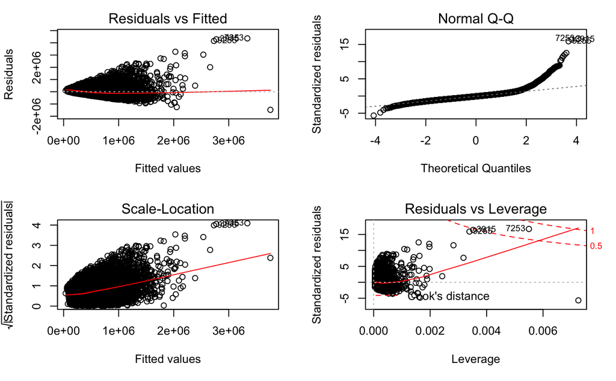

```r
par(mfrow = c(2, 2))
plot(kc_mod4)
```

kc_mod4 doesn’t look good at all. There is a trend on the “Scale-location” and on the “Normal” it doesn’t follow the dotted line.

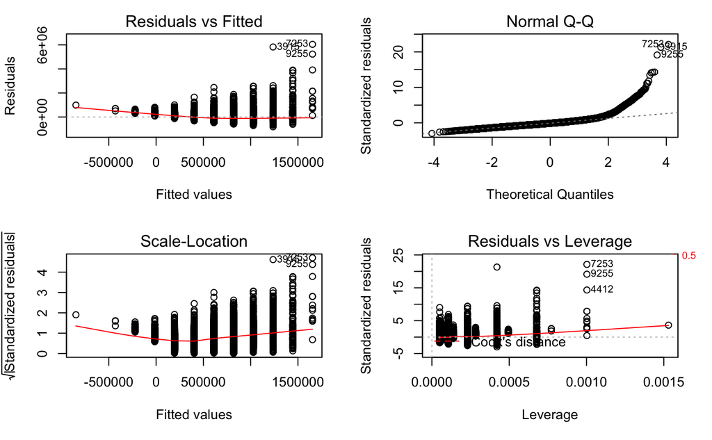

```r
par(mfrow = c(2, 2))
plot(kc_mod10)
```

kc_mod10 also doesn’t follow the normal posting properly.

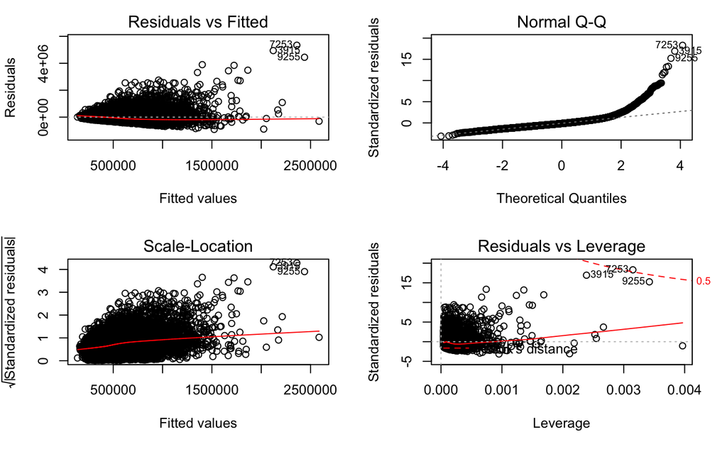

```r
par(mfrow = c(2, 2))
plot(kc_mod11)
```

kc_mod11 doesn’t fare much better.

```r
kc_mod17 <- lm(price ~ sqft_living + grade, data = kc_trim_dummy)
summary(kc_mod17
        )
```

```
Call:
lm(formula = price ~ sqft_living + grade, data = kc_trim_dummy)

Residuals:
     Min       1Q   Median       3Q      Max
-1065457  -138304   -25043   100447  4794633

Coefficients:
              Estimate Std. Error t value Pr(>|t|)
(Intercept) -5.981e+05  1.330e+04  -44.98   <2e-16 ***
sqft_living  1.844e+02  2.869e+00   64.29   <2e-16 ***
grade        9.855e+04  2.241e+03   43.97   <2e-16 ***
---
Signif. codes:  0 ‘***’ 0.001 ‘**’ 0.01 ‘*’ 0.05 ‘.’ 0.1 ‘ ’ 1

Residual standard error: 250500 on 21610 degrees of freedom
Multiple R-squared:  0.5345,    Adjusted R-squared:  0.5345
F-statistic: 1.241e+04 on 2 and 21610 DF,  p-value: < 2.2e-16
```

This is better yet.

```r
kc_mod18 <- lm(price ~ sqft_living + grade + sqft_above, data = kc_trim_dummy)
summary(kc_mod18)
```

```
Call:
lm(formula = price ~ sqft_living + grade + sqft_above, data = kc_trim_dummy)

Residuals:
     Min       1Q   Median       3Q      Max
-1119293  -136706   -24172    97173  4759450

Coefficients:
              Estimate Std. Error t value Pr(>|t|)
(Intercept) -6.512e+05  1.355e+04  -48.07   <2e-16 ***
sqft_living  2.347e+02  4.037e+00   58.13   <2e-16 ***
grade        1.100e+05  2.319e+03   47.43   <2e-16 ***
sqft_above  -7.771e+01  4.423e+00  -17.57   <2e-16 ***
---
Signif. codes:  0 ‘***’ 0.001 ‘**’ 0.01 ‘*’ 0.05 ‘.’ 0.1 ‘ ’ 1

Residual standard error: 248700 on 21609 degrees of freedom
Multiple R-squared:  0.5411,    Adjusted R-squared:  0.541
F-statistic:  8492 on 3 and 21609 DF,  p-value: < 2.2e-16
```

```r
anova(kc_mod18)
```

```
Analysis of Variance Table

Response: price
               Df     Sum Sq    Mean Sq  F value    Pr(>F)
sqft_living     1 1.4356e+15 1.4356e+15 23205.62 < 2.2e-16 ***
grade           1 1.2132e+14 1.2132e+14  1961.02 < 2.2e-16 ***
sqft_above      1 1.9092e+13 1.9092e+13   308.61 < 2.2e-16 ***
Residuals   21609 1.3369e+15 6.1866e+10
---
Signif. codes:  0 ‘***’ 0.001 ‘**’ 0.01 ‘*’ 0.05 ‘.’ 0.1 ‘ ’ 1
```

All 3 are siginifcantly impacting the price.